# R Notebook

```r
library(dplyr)
library(ggplot2)
library(lessR)
library(psych)
library(MASS)
library(car)
```

```r
data <- read.csv("ames_housing_data.csv", stringsAsFactors = TRUE)
```

##### (1) Preparing the Categorical Variables

This assignment assumes you are using the same Sample Population as from the previous modeling assignment. If you need to make adjustments to the Sample Population, please do so and report what you’ve done. Let Y = sale price be the dependent or response variable. Examine the categorical variables in the Ames Data Set. On first principles (i.e. your reasoning) which seem most likely to be related to, or predictive of, SALESPRICE? For those categorical variables that seem most reasonable or interesting, find summary statistics for Y (i.e. means, medians, std dev., etc) BY the levels of the categorical variable. Which categorical variable(s) have the greatest mean difference between levels? Why is this an important quality to look for? Create dummy coded (or effect coded, if you prefer) variables for the interesting categorical variables that may be predictive of SALEPRICE. Keep in mind, the more categorical variables you want to include in your analysis, the more work required in dealing with those variables. This work goes up exponentially with the number of categorical variables retained and their numbers of levels. Be brutally honest about the potential for a categorical variable to be predictive. If you must, fit regression models to determine R-squared for the categorical variables of interest, and then select only those that have reasonably large R-squared values. Report the summary statistics for SALESPRICE by group for these interesting categorical variables that you wish to retain for further analysis.  
***

```r
data_cat <- data[,sapply(data,is.factor)]
data_cat$SalePrice <-data$SalePrice
```

My thought process as a first pass is to run an ANOVA through all the categorical variables. The hypothesis for an ANOVA is as follows:  
$H_0$: The means within groups are the same.  
$H_a$: Not all the means are equal.  
If the means are equal, then we can conclude that there is no relationship between Sale price and the different groupings.

A loop is ran to calculate ANOVA and collect the p_value for all the categorical variables. If the P value is statistically significant at .05 level, then we can reject the null, and the ones that are significant will stay for further analysis.

```r
P_valFrame <- data.frame(character(44), numeric(44), stringsAsFactors = FALSE)
options(scipen = 999)
for(i in 1:length(data_cat)){
  z<-colnames(data_cat[i])
  P_valFrame[i,1] <- as.character(z)
  #assign(paste0("Variable_",z),(summary(aov(SalePrice~data[,i],data=data)))[[1]][1,5])
  P_valFrame[i,2]<-round(summary(aov(SalePrice~data_cat[,i],data=data_cat))[[1]][1,5],4)
         }
```

Of our 44 categorical variables, we were able to eliminate only 3, so we have 41 categorical variables to inspect. The ones that were not significant were: Utilities, PoolQC, and MiscFeature. We adjust our dataset to remove these variables.

```r
colnames(P_valFrame)<-c("Variable", "P(>F)")
subset(P_valFrame, P_valFrame$`P(>F)`<.05)
```

|  | Variable | P(>F) |
| --- | --- | --- |
| 1 | Zoning | 0.0000 |
| 2 | Street | 0.0013 |
| 3 | Alley | 0.0000 |
| 4 | LotShape | 0.0000 |
| 5 | LandContour | 0.0000 |
| 7 | LotConfig | 0.0000 |
| 8 | LandSlope | 0.0010 |
| 9 | Neighborhood | 0.0000 |
| 10 | Condition1 | 0.0000 |
| 11 | Condition2 | 0.0000 |

[output cut: 31 more lines]

```r
NA
NA
```

Removed the 3 insignificant variables

```r
data_cat <- subset(data_cat, select = -c(PoolQC, MiscFeature, Utilities))
```

Next, I’m going to generate a frequency table for each of the categorial variable. The idea is that if there is a heavy imbalance between a groupings, some of the data may not be meaningful in predicting price. For example, if there are 900 gravel homes and 10 Pavement homes, even if itsays Pavement homes have a higher sale price, it may be just because of thin data and is not credible. The output is not shown due to the length of the data.

Below are the frequency of the variables which I am opting to omit. The counts are fairly imbalanced and thin that I believe that any indication of relationship would not be credible

```r
table(data_cat$Street)
```

```
Grvl Pave
  12 2918
```

```r
table(data_cat$Condition2)
```

```
Artery  Feedr   Norm   PosA   PosN   RRAe   RRAn   RRNn
     5     13   2900      4      4      1      1      2
```

```r
table(data_cat$RoofMat)
```

```
ClyTile CompShg Membran   Metal    Roll Tar&Grv WdShake WdShngl
      1    2887       1       1       1      23       9       7
```

```r
table(data_cat$Heating)
```

```
Floor  GasA  GasW  Grav  OthW  Wall
    1  2885    27     9     2     6
```

```r
table(data_cat$CentralAir)
```

```
   N    Y
 196 2734
```

```r
table(data_cat$Functional)
```

```
Maj1 Maj2 Min1 Min2  Mod  Sal  Sev  Typ
  19    9   65   70   35    2    2 2728
```

```r
table(data_cat$GarageQual)
```

```
       Ex   Fa   Gd   Po   TA
   1    3  124   24    5 2615
```

```r
table(data_cat$GarageCond)
```

```
       Ex   Fa   Gd   Po   TA
   1    3   74   15   14 2665
```

```r
table(data_cat$PavedDrive)
```

```
   N    P    Y
 216   62 2652
```

After removing these variables, we not have 32 variables left to investigate.

```r
data_cat <-subset(data_cat, select = -c(Street,
                                        Condition2,
                                        RoofMat,
                                        Heating,
                                        CentralAir,
                                        Functional,
                                        GarageQual,
                                        GarageCond,
                                        PavedDrive))
```

My next thought is to run a simple OLS regression on each of the categorical variable to inspect the $R^2$ and the statistical significance. The hope is that these will narrow down a few more variables that I can use for my model.

The table below lists the variable with it’s adjusted $R^2$. Before I commit to any of these variables, I’m going to look at a few and just inspect the p-values for the individual groups. As long as they are not all insignficant, I think some of these variables will end up being decent predictors. As the adjusted $R^2$ are sorted from highest to lowest, I’ll just look at the top 5 and see.

```r
R_sqFrame <- data.frame(character(32), numeric(32), stringsAsFactors = FALSE)
options(scipen = 999)
for(i in 1:length(data_cat)){
  z<-colnames(data_cat[i])
  R_sqFrame[i,1] <- as.character(z)
  #assign(paste0("Variable_",z),(summary(aov(SalePrice~data[,i],data=data)))[[1]][1,5])
  R_sqFrame[i,2]<-summary(lm(SalePrice~data_cat[,i], data=data_cat))$adj.r.squared
  }

colnames(R_sqFrame)<-c("Variable", "adjusted.R.Squared")
R_sqFrame[order(-R_sqFrame$adjusted.R.Squared),]
```

[output not shown]

[output cut: 25 more lines]

```r
NA
```

Inspecting the model summary of each variable:  
Neighborhood seems decent. There’s a few insignificant variables, but most of them are significant.  
ExterQual has all significant variables.  
BsmtQual are insignificant for most groups, so I may not use that variable. KitchenQual seems important with all the variables being significant.  
Alley is also significant, but a lot of missing values were removed.

Overall, I think the variables that are most predicted will be Neighborhood, Exterior Quality, and Kitchen Quality. These variables follow intuition that they are what you would consider when purchasing a home, so it does pass the ‘common sense’ test.

```r
summary(lm(SalePrice~Neighborhood, data=data_cat))
```

```
Call:
lm(formula = SalePrice ~ Neighborhood, data = data_cat)

Residuals:
    Min      1Q  Median      3Q     Max
-194229  -26219   -4749   20237  424681

Coefficients:
                    Estimate Std. Error t value             Pr(>|t|)
(Intercept)           196662       9908  19.849 < 0.0000000000000002
NeighborhoodBlueste   -53072      19314  -2.748             0.006036
NeighborhoodBrDale    -91053      13776  -6.609 0.000000000045740734
NeighborhoodBrkSide   -71905      11118  -6.467 0.000000000116635108
NeighborhoodClearCr    12000      12674   0.947             0.343799
NeighborhoodCollgCr     5142      10414   0.494             0.621545
NeighborhoodCrawfor    10889      11174   0.975             0.329872
NeighborhoodEdwards   -65818      10599  -6.210 0.000000000605529694
NeighborhoodGilbert    -6015      10716  -0.561             0.574608
NeighborhoodGreens     -3130      21018  -0.149             0.881609
NeighborhoodGrnHill    83338      38373   2.172             0.029952
NeighborhoodIDOTRR    -92909      11301  -8.221 0.000000000000000301
NeighborhoodLandmrk   -59662      53355  -1.118             0.263577
NeighborhoodMeadowV  -100905      13132  -7.684 0.000000000000020972
NeighborhoodMitchel   -34435      11058  -3.114             0.001863
NeighborhoodNAmes     -51564      10216  -5.047 0.000000475687007474
NeighborhoodNoRidge   133657      11700  11.424 < 0.0000000000000002
NeighborhoodNPkVill   -55951      14754  -3.792             0.000152
NeighborhoodNridgHt   125357      10711  11.704 < 0.0000000000000002
NeighborhoodNWAmes     -8255      10916  -0.756             0.449563
NeighborhoodOldTown   -72670      10472  -6.939 0.000000000004839387
NeighborhoodSawyer    -59910      10787  -5.554 0.000000030491120076
NeighborhoodSawyerW   -12592      10962  -1.149             0.250774
NeighborhoodSomerst    33046      10643   3.105             0.001921
NeighborhoodStoneBr   127568      12331  10.345 < 0.0000000000000002
NeighborhoodSWISU     -61590      12467  -4.940 0.000000824753729743
NeighborhoodTimber     49938      11676   4.277 0.000019573983153912
NeighborhoodVeenker    51653      14584   3.542             0.000404

Residual standard error: 52430 on 2902 degrees of freedom
Multiple R-squared:  0.5733,    Adjusted R-squared:  0.5693
F-statistic: 144.4 on 27 and 2902 DF,  p-value: < 0.00000000000000022
```

```r
summary(lm(SalePrice~ExterQual, data=data_cat))
```

```
Call:
lm(formula = SalePrice ~ ExterQual, data = data_cat)

Residuals:
    Min      1Q  Median      3Q     Max
-217919  -33374   -5874   24714  514244

Coefficients:
            Estimate Std. Error t value            Pr(>|t|)
(Intercept)   377919       5438   69.50 <0.0000000000000002
ExterQualFa  -287995      10953  -26.29 <0.0000000000000002
ExterQualGd  -147162       5724  -25.71 <0.0000000000000002
ExterQualTA  -234545       5597  -41.90 <0.0000000000000002

Residual standard error: 56250 on 2926 degrees of freedom
Multiple R-squared:  0.5047,    Adjusted R-squared:  0.5042
F-statistic:   994 on 3 and 2926 DF,  p-value: < 0.00000000000000022
```

```r
summary(lm(SalePrice~BsmtQual, data=data_cat))
```

```
Call:
lm(formula = SalePrice ~ BsmtQual, data = data_cat)

Residuals:
    Min      1Q  Median      3Q     Max
-233369  -29847   -6347   23273  421631

Coefficients:
            Estimate Std. Error t value   Pr(>|t|)
(Intercept)    79000      56182   1.406     0.1598
BsmtQualEx    254369      56291   4.519 0.00000647
BsmtQualFa     30635      56500   0.542     0.5877
BsmtQualGd    122727      56205   2.184     0.0291
BsmtQualPo      5950      68809   0.086     0.9311
BsmtQualTA     60847      56204   1.083     0.2791

Residual standard error: 56180 on 2845 degrees of freedom
  (79 observations deleted due to missingness)
Multiple R-squared:  0.5048,    Adjusted R-squared:  0.5039
F-statistic:   580 on 5 and 2845 DF,  p-value: < 0.00000000000000022
```

```r
summary(lm(SalePrice~KitchenQual, data=data_cat))
```

```
Call:
lm(formula = SalePrice ~ KitchenQual, data = data_cat)

Residuals:
    Min      1Q  Median      3Q     Max
-251339  -32136   -4550   25450  417661

Coefficients:
              Estimate Std. Error t value             Pr(>|t|)
(Intercept)     337339       4018  83.949 < 0.0000000000000002
KitchenQualFa  -231432       7965 -29.057 < 0.0000000000000002
KitchenQualGd  -126504       4359 -29.021 < 0.0000000000000002
KitchenQualPo  -229839      57675  -3.985            0.0000691
KitchenQualTA  -197789       4285 -46.156 < 0.0000000000000002

Residual standard error: 57530 on 2925 degrees of freedom
Multiple R-squared:  0.482, Adjusted R-squared:  0.4813
F-statistic: 680.5 on 4 and 2925 DF,  p-value: < 0.00000000000000022
```

```r
summary(lm(SalePrice~Alley, data=data_cat))
```

```
Call:
lm(formula = SalePrice ~ Alley, data = data_cat)

Residuals:
    Min      1Q  Median      3Q     Max
-136945  -20557   -3557   19418  168055

Coefficients:
            Estimate Std. Error t value            Pr(>|t|)
(Intercept)   123557       3579  34.525 <0.0000000000000002
AlleyPave      53388       5702   9.363 <0.0000000000000002

Residual standard error: 39200 on 196 degrees of freedom
  (2732 observations deleted due to missingness)
Multiple R-squared:  0.3091,    Adjusted R-squared:  0.3055
F-statistic: 87.67 on 1 and 196 DF,  p-value: < 0.00000000000000022
```

```r
data_cat <- subset(data, select=c(SalePrice,Neighborhood, ExterQual, KitchenQual))
```

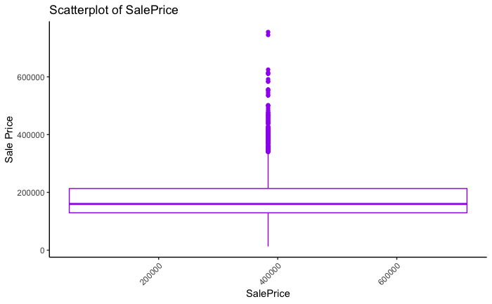

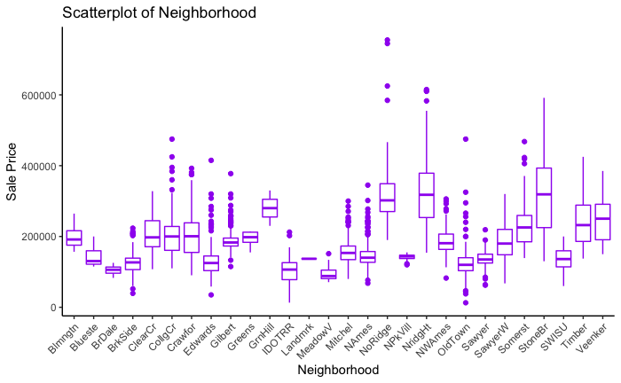

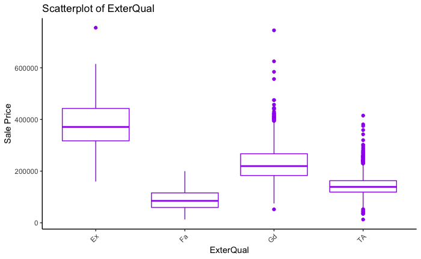

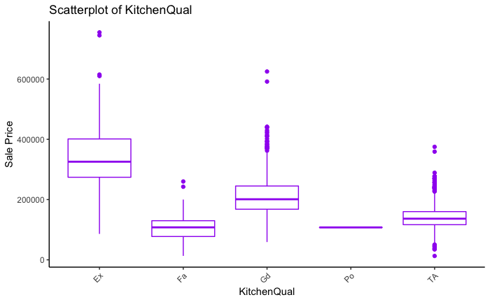

```r
for(i in 1:length(data_cat)){
    print(
      ggplot(data_cat, aes(x=data_cat[,i], y=SalePrice)) + geom_boxplot(col = "purple") + theme_classic() + theme(axis.text.x = element_text(angle = 45, hjust=1))+
      labs(x=colnames(data_cat[i]),
           y="Sale Price",title = paste0("Scatterplot of"," ",colnames(data_cat[i]))))
}
```

A residual analysis of the variables doesn’t indicate the residuals to be completely out of line. They aren’t perfectly “normal” and residuals are not completly random, but I think it would be okay to investigate and see where we end up.

```
not plotting observations with leverage one:
  2789
```

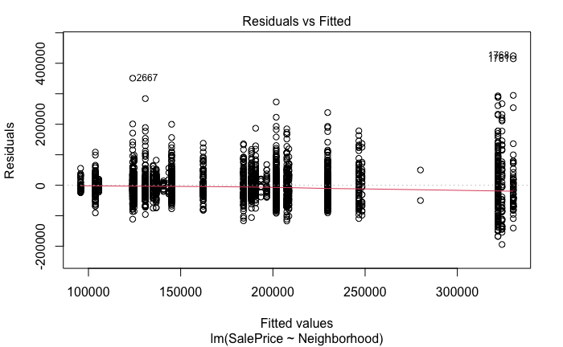

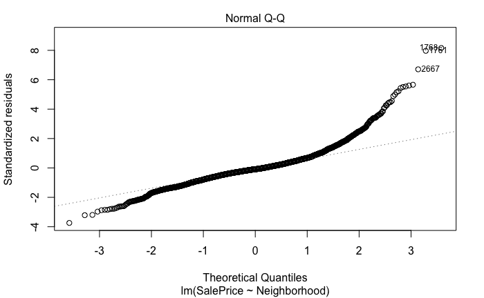

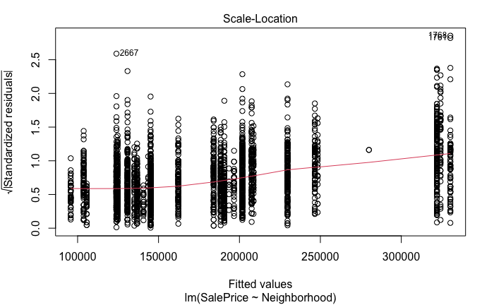

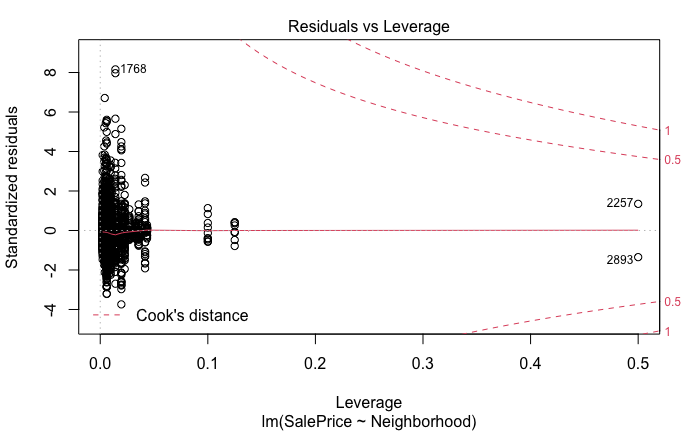

```r
plot((lm(SalePrice~Neighborhood, data=data_cat)))
```

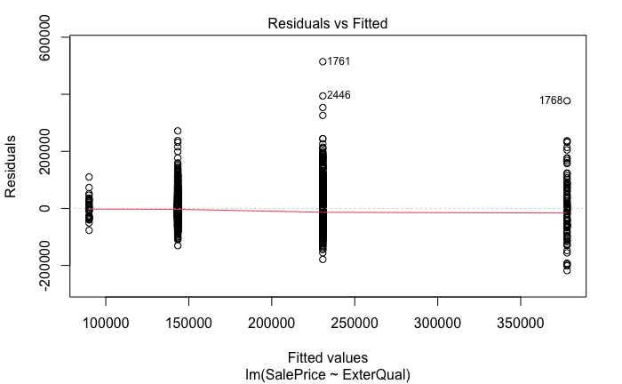

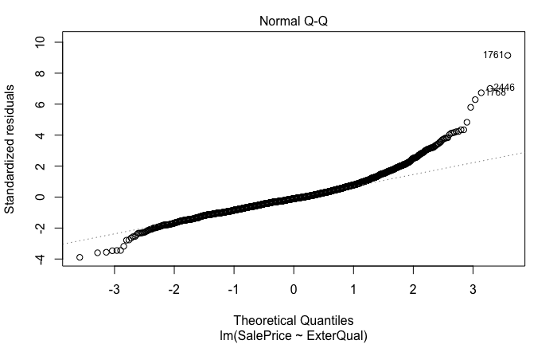

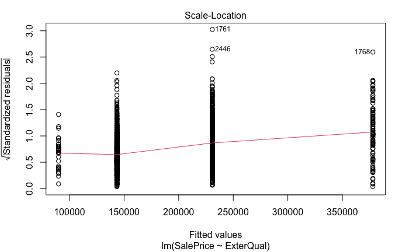

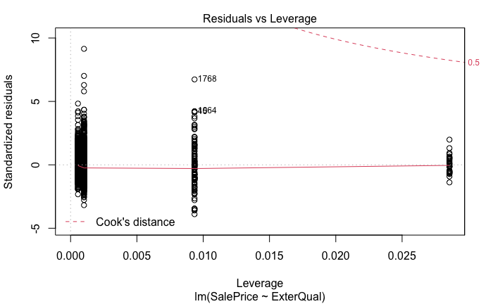

```r
plot((lm(SalePrice~ExterQual, data=data_cat)))
```

```
not plotting observations with leverage one:
  211
```

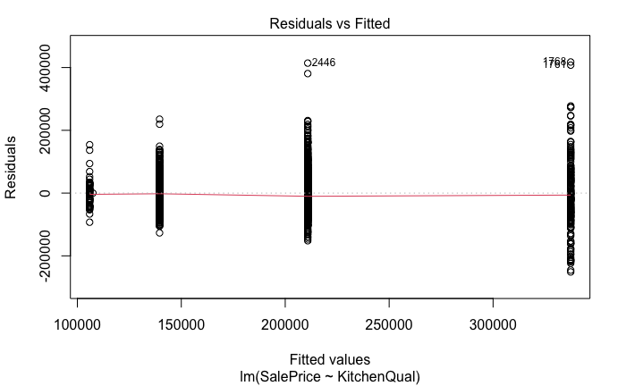

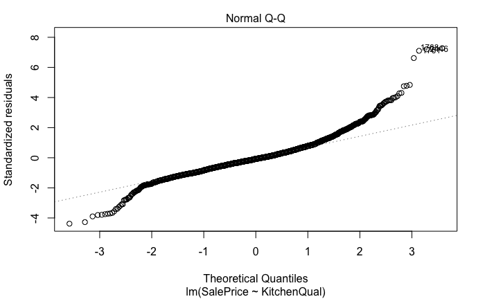

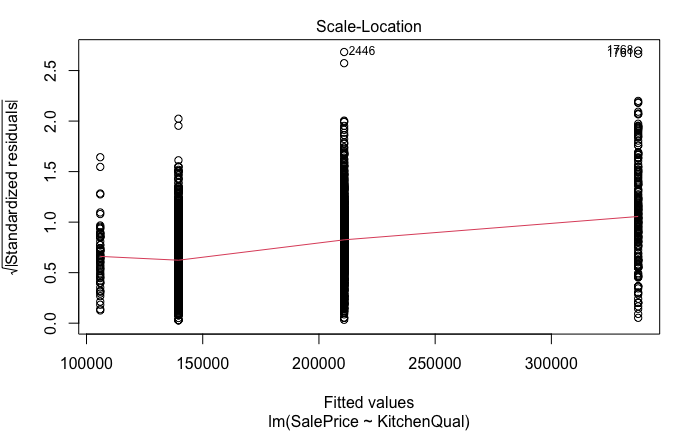

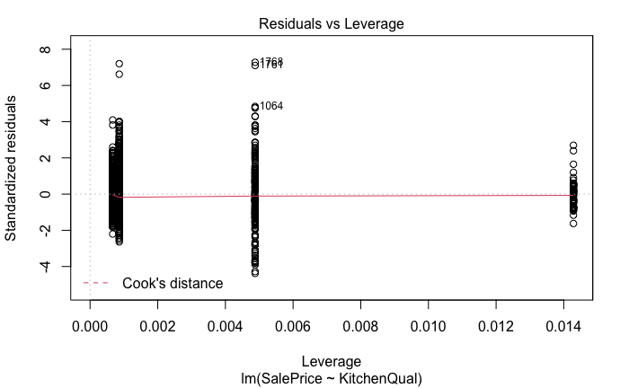

```r
plot((lm(SalePrice~KitchenQual, data=data_cat)))
```

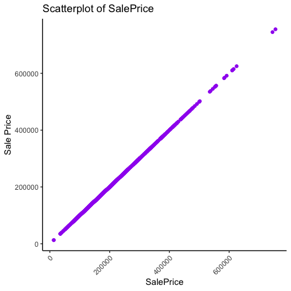

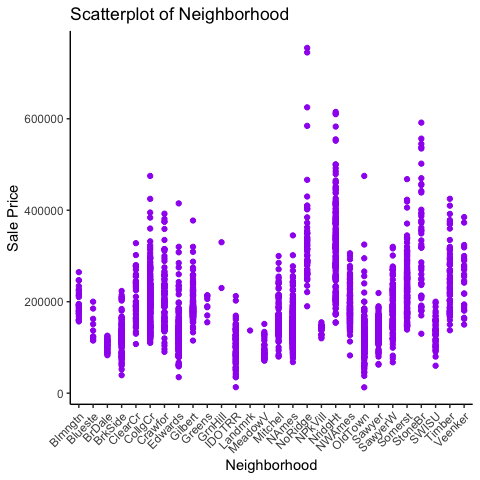

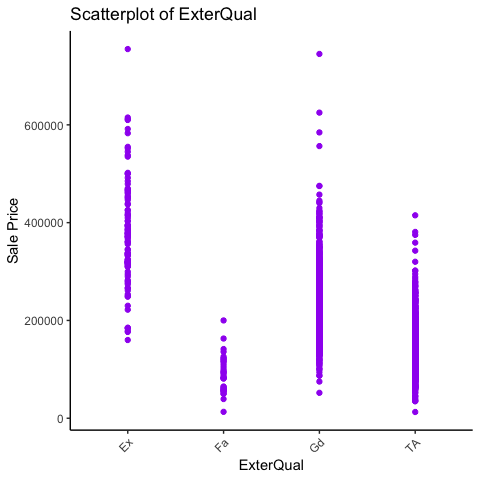

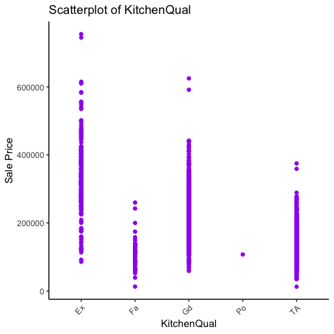

```r
for(i in 1:length(data_cat)){
    print(
      ggplot(data_cat, aes(x=data_cat[,i], y=SalePrice)) + geom_point(col = "purple") + theme_classic() + theme(axis.text.x = element_text(angle = 45, hjust=1))+
      labs(x=colnames(data_cat[i]),
           y="Sale Price",title = paste0("Scatterplot of"," ",colnames(data_cat[i]))))
}
```

```r
NA
NA
```

For this exercise, I will use Exerior quality and Kitchen as my final 2 variables to investigate. I think it would be interesting to have 1 variable that is exterior versus one variable that is interior and see what happens. Neighborhood is pretty predictive since it has the highest $R^2$, but I think neighborhood is pretty complex (there’s a few insignificant variables, geographic location will matter, and some may can potentially be grouped together), that I’m opting to start with something simple for now and see where it takes me.

```r
catvar <- data_cat[,c("SalePrice","ExterQual","KitchenQual")]
```

```r
tapply(catvar$SalePrice,catvar$ExterQual, summary)
```

```
$Ex
   Min. 1st Qu.  Median    Mean 3rd Qu.    Max.
 160000  317250  370967  377919  442520  755000

$Fa
   Min. 1st Qu.  Median    Mean 3rd Qu.    Max.
  13100   59500   85000   89924  115750  200000

$Gd
   Min. 1st Qu.  Median    Mean 3rd Qu.    Max.
  52000  183000  219500  230756  267300  745000

$TA
   Min. 1st Qu.  Median    Mean 3rd Qu.    Max.
  12789  119000  139000  143374  163000  415000
```

```r
tapply(catvar$SalePrice,catvar$ExterQual, sd)
```

```
       Ex        Fa        Gd        TA
106987.71  38013.50  70411.14  41503.85
```

Summary statistics of Kitchen Quality:  
The mean difference between the highest and lowest is 337,339-105,907 = 231,432

```r
tapply(catvar$SalePrice,catvar$KitchenQual, summary)
```

```
$Ex
   Min. 1st Qu.  Median    Mean 3rd Qu.    Max.
  86000  274000  325624  337339  401179  755000

$Fa
   Min. 1st Qu.  Median    Mean 3rd Qu.    Max.
  13100   77375  107750  105907  129750  260000

$Gd
   Min. 1st Qu.  Median    Mean 3rd Qu.    Max.
  59000  167960  201000  210836  245000  625000

$Po
   Min. 1st Qu.  Median    Mean 3rd Qu.    Max.
 107500  107500  107500  107500  107500  107500

$TA
   Min. 1st Qu.  Median    Mean 3rd Qu.    Max.
  12789  116600  136500  139550  160000  375000
```

```r
tapply(catvar$SalePrice,catvar$KitchenQual, sd)
```

```
       Ex        Fa        Gd        Po        TA
114361.31  41974.72  63585.01        NA  38447.77
```

```r
data$dummyExterior.Ex <- ifelse(catvar$ExterQual == "Ex",1,0)
data$dummyExterior.Fa <- ifelse(catvar$ExterQual == "Fa",1,0)
data$dummyExterior.Gd <- ifelse(catvar$ExterQual == "Gd",1,0)
data$dummyExterior.TA <- ifelse(catvar$ExterQual == "TA",1,0)

data$dummyKitchen.Ex <- ifelse(catvar$KitchenQual=="Ex", 1,0)
data$dummyKitchen.Fa <- ifelse(catvar$KitchenQual=="Fa", 1,0)
data$dummyKitchen.Gd <- ifelse(catvar$KitchenQual=="Gd", 1,0)
data$dummyKitchen.Po <- ifelse(catvar$KitchenQual=="Po", 1,0)
data$dummyKitchen.TA <- ifelse(catvar$KitchenQual=="TA", 1,0)
```

##### (2) The Predictive Modeling Framework

A defining feature of predictive modeling is assessing model performance out-of-sample. We will use uniform random number to split the sample into a 70/30 train/test split. With a train/test split we now have two data sets: one for in-sample model development and one for out-of-sample model assessment.

```r
# Set the seed on the random number generator so you get the same split every time that you run the code.
set.seed(123)
data$u <- runif(n=dim(data)[1],min=0,max=1);

# Define these two variables for later use;
data$QualityIndex <- data$OverallQual*data$OverallCond;
data$TotalSqftCalc <- data$BsmtFinSF1+data$BsmtFinSF2+data$GrLivArea;

# Create train/test split;
train.df <- subset(data, u<0.70)
test.df  <- subset(data, u>=0.70)

# Check your data split. The sum of the parts should equal the whole.
# Do your totals add up?
dim(data)[1]
```

```
[1] 2930
```

```r
dim(train.df)[1]+dim(test.df)[1]
```

```
[1] 2930
```

##### Our 70/30 training/test split is the most basic form of cross-validation. We will ‘train’ each model by estimating the models on the 70% of the data identified as the training data set, and we will ‘test’ each model by examining the predictive accuracy on the 30% of the data. In R will estimate our models using the lm() function, and we will be able to apply those linear models using the R function predict(). You will want to read the R help page for the R function predict(). In particular, pay attention to the newdata argument. Your test data set is your new data.

Show a table of observation counts for your train/test data partition in your data section.

```r
dim(train.df)[1]
```

```
[1] 2049
```

```r
dim(test.df)[1]
```

```
[1] 881
```

##### (3) Model Identification by Automated Variable Selection

Create a pool of candidate predictor variables. This pool of candidate predictor variables needs to have at least 15-20 predictor variables, you can have more. The variables should be a mix of discrete and continuous variables. You can include dummy coded or effect coded variables, but not the original categorical variables. Include a well-designed list or table of your pool of candidate predictor variables in your report. NOTE: If you need to create additional predictor variables, then you will want to create those predictor variables before you perform the train/test split outlined in (2). Also note that we will be using our two variables QualityIndex and TotalSqftCalc in this section. The easiest way to use variable selection in R is to use some R tricks. If you have small data sets (small number of columns), then these tricks are not necessary. However, if you have large data sets (large number of columns), then these tricks are NECESSARY in order to use variable selection in R effectively and easily.  
Trick #1: we need to create a data frame that only contains our response variable and the predictor variables that we want to include as our pool of predictor variables. We will do this by creating a drop list and using the drop list to shed the unwanted columns from train.df to create a ‘clean’ data frame.

Variables chosen: LotFrontage LotArea OverallQual OverallCond YearBuilt YearRemodel MasVnrArea TotalBsmtSF GrLivArea TotRmsAbvGrd Fireplaces OpenPorchSF PoolArea BedroomAbvGr KitchenAbvGr

Factor: KitchenQual -dummied ExternalQual -dummied

```r
candidateModel <-train.df[,c("LotFrontage","LotArea","OverallQual","OverallCond","YearBuilt","YearRemodel","MasVnrArea","TotalBsmtSF","GrLivArea","TotRmsAbvGrd","Fireplaces", "OpenPorchSF","PoolArea","BedroomAbvGr","KitchenAbvGr", "SalePrice", "QualityIndex","TotalSqftCalc", "dummyExterior.Ex","dummyExterior.Fa","dummyExterior.Gd","dummyExterior.TA","dummyKitchen.Ex","dummyKitchen.Fa","dummyKitchen.Gd","dummyKitchen.Po","dummyKitchen.TA")]

candidateModel_test <-test.df[,c("LotFrontage","LotArea","OverallQual","OverallCond","YearBuilt","YearRemodel","MasVnrArea","TotalBsmtSF","GrLivArea","TotRmsAbvGrd","Fireplaces", "OpenPorchSF","PoolArea","BedroomAbvGr","KitchenAbvGr", "SalePrice", "QualityIndex","TotalSqftCalc", "dummyExterior.Ex","dummyExterior.Fa","dummyExterior.Gd","dummyExterior.TA","dummyKitchen.Ex","dummyKitchen.Fa","dummyKitchen.Gd","dummyKitchen.Po","dummyKitchen.TA")]


#imputing missing valules with medians


candidateModel$LotFrontage<-ifelse(is.na(candidateModel$LotFrontage), median(candidateModel$LotFrontage,na.rm = TRUE),candidateModel$LotFrontage)
candidateModel$MasVnrArea<-ifelse(is.na(candidateModel$MasVnrArea), median(candidateModel$MasVnrArea,na.rm = TRUE),candidateModel$MasVnrArea)
candidateModel$TotalBsmtSF<-ifelse(is.na(candidateModel$TotalBsmtSF), median(candidateModel$TotalBsmtSF,na.rm = TRUE),candidateModel$TotalBsmtSF)
candidateModel$TotalSqftCalc<-ifelse(is.na(candidateModel$TotalSqftCalc), median(candidateModel$TotalSqftCalc,na.rm = TRUE),candidateModel$TotalSqftCalc)

candidateModel_test$LotFrontage<-ifelse(is.na(candidateModel_test$LotFrontage), median(candidateModel_test$LotFrontage,na.rm = TRUE),candidateModel_test$LotFrontage)
candidateModel_test$MasVnrArea<-ifelse(is.na(candidateModel_test$MasVnrArea), median(candidateModel_test$MasVnrArea,na.rm = TRUE),candidateModel_test$MasVnrArea)
candidateModel_test$TotalBsmtSF<-ifelse(is.na(candidateModel_test$TotalBsmtSF), median(candidateModel_test$TotalBsmtSF,na.rm = TRUE),candidateModel_test$TotalBsmtSF)
candidateModel_test$TotalSqftCalc<-ifelse(is.na(candidateModel_test$TotalSqftCalc), median(candidateModel_test$TotalSqftCalc,na.rm = TRUE),candidateModel_test$TotalSqftCalc)
```

```r
######remove the basis of interpretation for categorical!!!
upper.lm <-lm(SalePrice~., data=candidateModel)
lower.lm <- lm(SalePrice~1, data=candidateModel)
sqft.lm <- lm(SalePrice~TotalSqftCalc, data=candidateModel)
```

```r
forward.lm <-stepAIC(object=lower.lm, scope = list(upper=formula(upper.lm), lower=~1), direction=c('forward'))
backward.lm <-stepAIC(object=upper.lm, scope = list(upper=formula(upper.lm), lower=~1), direction=c('backward'))
stepwise.lm <-stepAIC(object=sqft.lm, scope = list(upper=formula(upper.lm), lower=~1), direction=c('both'))
```

```r
sum.f<-summary(forward.lm)
sum.b<-summary(backward.lm)
sum.s<-summary(stepwise.lm)
sum.j<-summary(junk.lm)

sum.f
sum.b
sum.s
sum.j
```

[output not shown]

```r
junk.lm <- lm(SalePrice ~ OverallQual + OverallCond + QualityIndex + GrLivArea + TotalSqftCalc, data=train.df)
summary(junk.lm)
```

[output not shown]

With all the variables chosen, as there is chance of multicollinearity, we will look at the variance inflation factors of each predictor. VIF works by running a regression of each predictor on the remaining preditors, and uses that $R^2$ to determine multicollinearity. Essentially, if all the other variables are able to explain the variance of the predictor variable in question (high $R^2$), then there is a chance that it is multicollinearity. The formula $\frac{1}{1-R^2}$ is the “inflation” factor used. Anything above 5, we will say is inflated with at least one of the predictors.

```r
forward.vif<-sort(vif(forward.lm), decreasing=TRUE)
backward.vif<-sort(vif(backward.lm), decreasing=TRUE)
step.vif<-sort(vif(stepwise.lm), decreasing = TRUE)
```

```r
forward.vif
```

[output not shown]

```r
backward.vif
```

[output not shown]

```r
step.vif
```

[output not shown]

```r
Adjusted.R <- c(sum.f$adj.r.squared, sum.b$adj.r.squared, sum.s$adj.r.squared,sum.j$adj.r.squared)
AIC <- c(AIC(forward.lm), AIC(backward.lm), AIC(stepwise.lm), AIC(junk.lm))
BIC <- c(BIC(forward.lm), BIC(backward.lm), BIC(stepwise.lm), BIC(junk.lm))
MSE <-c(mean(sum.f$residuals^2), mean(sum.b$residuals^2), mean(sum.s$residuals^2), mean(sum.j$residuals^2))
MAE <- c(mean((abs(sum.f$residuals))),mean((abs(sum.b$residuals))),mean((abs(sum.s$residuals))),mean((abs(sum.j$residuals))))

modelCompare<-data.frame(rbind(round(adj.r,4), round(AIC,4), round(BIC,4), round(MSE,4), round(MAE,4)))
colnames(modelCompare)<-c("ForwardSelection", "BackwardSelection", "Stepwise", "Junk")
modelCompare
```

[output not shown]

##### In predictive modeling, we are interested in how well our model performs (predicts) out-of-sample. That is the point of predictive modeling. For each of the four models compute the Mean Squared Error (MSE) and the Mean Absolute Error (MAE) for the test sample. Which model fits the best based on these criteria? Did the model that fit best in-sample predict the best out-of-sample? Should we have a preference for the MSE or the MAE? What does it mean when a model has better predictive accuracy in-sample then it does out-of-sample?

```r
forward.test <- predict(forward.lm, newdata=candidateModel_test)
backward.test <- predict(backward.lm, newdata=candidateModel_test)
step.test <- predict(stepwise.lm, newdata=candidateModel_test)
junk.test <-predict(junk.lm, newdata=candidateModel_test)
```

```r
test.df$forward.predicted <- forward.test
test.df$forwardDiff <- test.df$forward.predicted-test.df$SalePrice

test.df$backward.predicted <- backward.test
test.df$backwardDiff <- test.df$backward.predicted-test.df$SalePrice

test.df$step.predicted <- step.test
test.df$stepDiff <- test.df$step.predicted-test.df$SalePrice

test.df$junk.predicted <- junk.test
test.df$junkDiff <- test.df$junk.predicted-test.df$SalePrice

MSE <-c(mean((test.df$forwardDiff^2)), mean((test.df$backwardDiff^2)), mean((test.df$stepDiff^2)), mean((test.df$junkDiff^2)))
MAE <-c(mean(abs(test.df$forwardDiff)), mean(abs(test.df$backwardDiff)), mean(abs(test.df$stepDiff)), mean(abs(test.df$junkDiff)))

modelCompare_test<-data.frame(rbind(round(MSE,4), round(MAE,4)))
colnames(modelCompare_test)<-c("ForwardSelection", "BackwardSelection", "Stepwise", "Junk")
modelCompare_test
```

| ForwardSelection | BackwardSelection | Stepwise | Junk |
| --- | --- | --- | --- |
| 1041171967.90 | 1036452945.09 | 1041171967.90 | 1469005635.13 |
| 19314.92 | 19182.59 | 19314.92 | 25449.38 |

```r
NA
```

##### (5) Operational Validation

We have validated these models in the statistical sense, but what about the business sense? Do MSE or MAE easily translate to the development of a business policy? Typically, in applications we need to be able to hit defined cut-off points, i.e. we set a policy that we need to be p% accurate. Let’s define a variable called PredictionGrade, and consider the predicted value to be ‘Grade 1’ if it is within ten percent of the actual value, ‘Grade 2’ if it is not Grade 1 but within fifteen percent of the actual value, Grade 3 if it is not Grade 2 but within twenty-five percent of the actual value, and ‘Grade 4’ otherwise.

```r
# Training Data
# Abs Pct Error
forward.pct <- abs(forward.lm$residuals)/candidateModel$SalePrice;

# Assign Prediction Grades;
forward.PredictionGrade <- ifelse(forward.pct<=0.10,'Grade 1: [0.0.10]',
                    ifelse(forward.pct<=0.15,'Grade 2: (0.10,0.15]',
                        ifelse(forward.pct<=0.25,'Grade 3: (0.15,0.25]',
                        'Grade 4: (0.25+]')
                    )
                )

forward.trainTable <- table(forward.PredictionGrade)
forward.trainTable/sum(forward.trainTable)


# Test Data
# Abs Pct Error
forward.testPCT <- abs(candidateModel_test$SalePrice-forward.test)/candidateModel_test$SalePrice;
backward.testPCT <- abs(candidateModel_test$SalePrice-backward.test)/candidateModel_test$SalePrice;
stepwise.testPCT <- abs(candidateModel_test$SalePrice-step.test)/candidateModel_test$SalePrice;
junk.testPCT <- abs(candidateModel_test$SalePrice-junk.test)/candidateModel_test$SalePrice;


# Assign Prediction Grades;
forward.testPredictionGrade <- ifelse(forward.testPCT<=0.10,'Grade 1: [0.0.10]',
                    ifelse(forward.testPCT<=0.15,'Grade 2: (0.10,0.15]',
                        ifelse(forward.testPCT<=0.25,'Grade 3: (0.15,0.25]',
                        'Grade 4: (0.25+]')
                    )
                )

forward.testTable <-table(forward.testPredictionGrade)
data.frame(forward.testTable/sum(forward.testTable))
```

[output not shown]

##### For reflection / conclusions: After working on this problem and this data for several weeks, what are the challenges presented by the data? What are your recommendations for improving predictive accuracy? What do you think of the notion of parsimony: simpler models might be preferable over complicated models? Do we really need a max fit model or is a simpler but more interpretable model better?

Going through this assignment, There was definitley a “5 steps forward 1 step backward” feeling. I learned quite a bit of new techniques to think about to consider, and while that is helpful in the analysis, the more I know, the more I realized there’s a responsibility in making sure I perform my analysis in a statistically correct manner. I would say I do have a bit of a “phobia” when it comes to running models and tests. The main reason is because of the assumptions and fact that I’m still trying to understand how much I can get away with breaking assumptions (since nothing is every perfectly normal). The biggest challenge in this problem set was just setting up the data with Question 1. With adding categorical variables to the data, it seemed to become way more complicated to assess correlation and $R^2$. The more you dummy the variables, the more complicated the model becomes and translates to more work by the modelor. In the best case scenario, there would be a way to write a function to automate the manual process and improve effeciency. With enough time given, I would have also probably done a better job to impute data; potentially use regression method to derive values for missing entries, rather than just take the median. I think more business knowledge would also be needed. Especially with the neighborhoods and other variables which are not ordered, it would be nice to potentially group them together to increase data counts in some variables.